# Red Wine Exploration by Julie Tang

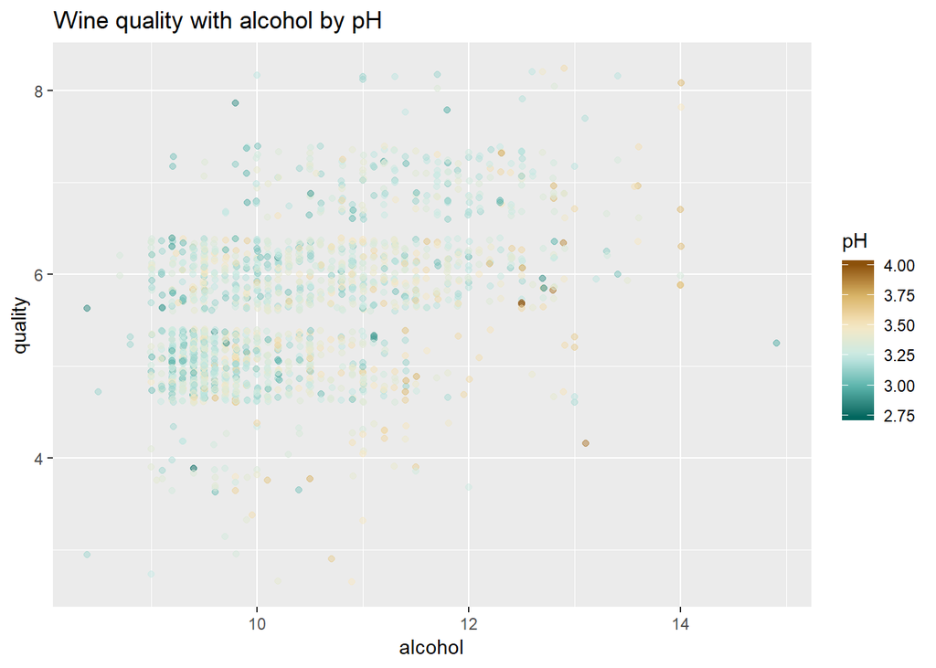

The correlation between alcohol and quality is supposed to be the strongest comparing to other attributes. By adding pH, we can see different pH levels spread the whole plot. But it looks higher pH cluster more on higher percent alcohol side. And lower pH culster more on lower percent alcohol side. The pair plots show pH and Alcohol’s col value is 0.206. So they are somewhat correlated.

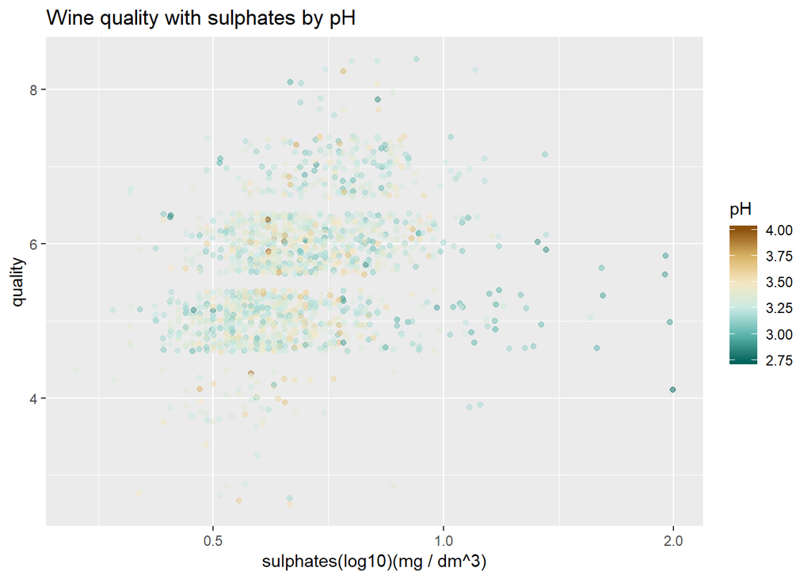

In the bivariate plots we have concluded sulphates and quality are correlated. In this plot after adding pH, we can see samples with different pH spread everywhere. Again it seems pH doesn’t have much correlation with quality. From this plot, it’s interesting to see the samples with sulphates higher than 1 generally have lower pH and associated with quality level lower than 6.

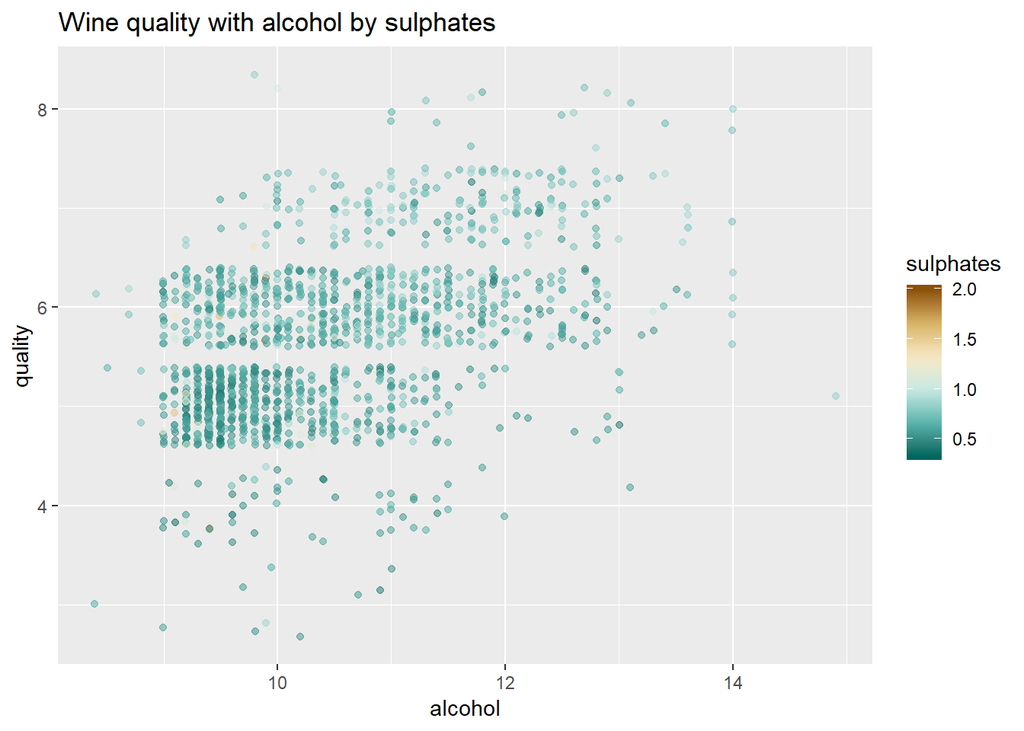

Both alcohol and sulphates have positive correlation with quality. When putting these three variables together, it looks there is a mild trend of higher alcohol, higer sulphates(under 1) have higher quality. But the correlation is not strong.

```
##
## Calls:
## m1: lm(formula = quality ~ alcohol, data = red_wine)
## m2: lm(formula = quality ~ alcohol + pH, data = red_wine)
## m3: lm(formula = quality ~ alcohol + pH + I(log(sulphates)), data = red_wine)
## m4: lm(formula = quality ~ alcohol + pH + I(log(sulphates)) + volatile.acidity,
##     data = red_wine)
##
## =============================================================================
##                           m1            m2            m3            m4
## -----------------------------------------------------------------------------
##   (Intercept)            1.875***      4.426***      4.357***      4.240***
##                         (0.175)       (0.387)       (0.375)       (0.362)
##   alcohol                0.361***      0.386***      0.356***      0.316***
##                         (0.017)       (0.017)       (0.016)       (0.016)
##   pH                                  -0.850***     -0.625***     -0.317**
##                                       (0.116)       (0.114)       (0.114)
##   I(log(sulphates))                                  0.819***      0.616***
##                                                     (0.078)       (0.077)
##   volatile.acidity                                                -1.086***
##                                                                   (0.100)
## -----------------------------------------------------------------------------
##   R-squared              0.227         0.252         0.301         0.349
##   adj. R-squared         0.226         0.251         0.299         0.347
##   sigma                  0.710         0.699         0.676         0.653
##   F                    468.267       268.888       228.624       213.327
##   p                      0.000         0.000         0.000         0.000
##   Log-likelihood     -1721.057     -1694.466     -1640.666     -1583.855
##   Deviance             805.870       779.508       728.780       678.792
##   AIC                 3448.114      3396.931      3291.331      3179.711
##   BIC                 3464.245      3418.440      3318.217      3211.974
##   N                   1599          1599          1599          1599
## =============================================================================
```

The variables in this linear model can only account to 34.9% of the variance in the quality of red wine. We continue to do the log transformation on Sulphates.

# Multivariate Analysis

### Talk about some of the relationships you observed in this part of the investigation. Were there features that strengthened each other in terms of looking at your feature(s) of interest?

To be honest, I don’t see any attribute has strong correlation with quality. It’s hard to say which attribute is most critical to predict the wine’s quality. Though from correlation coefficient’s perspective, the alcohol is most correlated with quality, the corrlation is still not strong.

But when putting alcohol, sulphates and quality in the same plot, we can see generally the samples with higher alcohol and higher sulphates(but lower than 1) has the trend to be higher quality. This is reasonable because both alcohol and sulphate (under 1) have positive correlation with quality.

### Were there any interesting or surprising interactions between features?

pH seems can’t predict the quality at all. While doing the research to understand what might contribute to wine’s quality, pH seems always be the top one. I suppose the plot should show some correlation between pH and quality. But no matter where I add pH it spreads everywhere.

### OPTIONAL: Did you create any models with your dataset? Discuss the strengths and limitations of your model.

Yes, I created a linear model that included alcohol, sulphates, pH and volatile acidity variables and wine quality as the output variable. The limitation of this linear model is that variables in this linear model can only account for 34.9% of the variance in the quality of red wine. The strengths is that we can still tell some correlations between the predictors and output variable and by adding additonal variable we got higher r-squared value.

# Final Plots and Summary

### Plot One

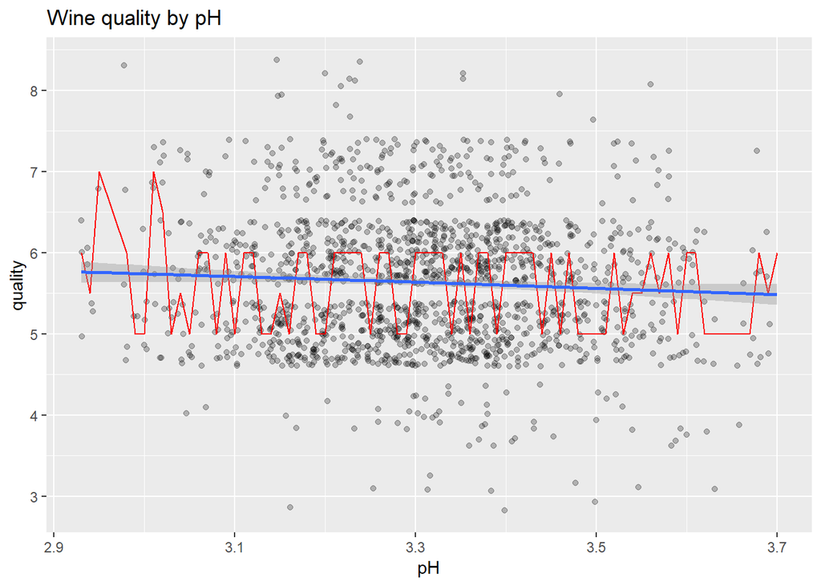

### Description One

This Plot shows the relationship between pH and quality. I excluded the samples with bottom 1% and top 1% of pH to explain the majority of samples to avoid the interrupt of extreme cases. Though there is no direct correlation between pH and quality, we can see pH is mostly between 3.1 and 3.5 for the samples with high quality(7 or 8). Since the majority samples’ pH is between 3.0 and 3.7, the range is narrow. Maybe that can also explain why we don’t see much correlation between pH and quality. When pH is above 3.6, we can see there are few samples with high quality. If the pH’s range is bigger, maybe we can see its impact on the quality.

### Plot Two

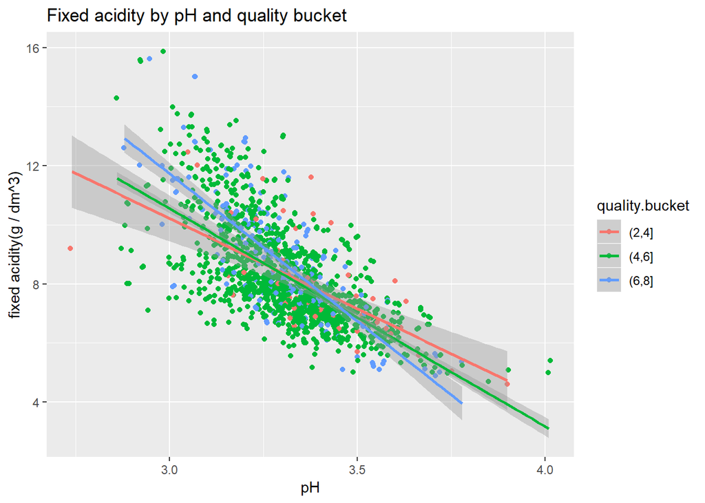

### Description Two

The plot above shows the correlation between pH and fixed acidity. The correlation between these two attributes are the strongest among all the attributes. I split the quality level into 3 buckets:(2,4],(4, 6], (6, 8]. It’s interesting to see that if we use lm smoothing method, the slope of higher quality is steeper than the lower quality.

### Plot Three

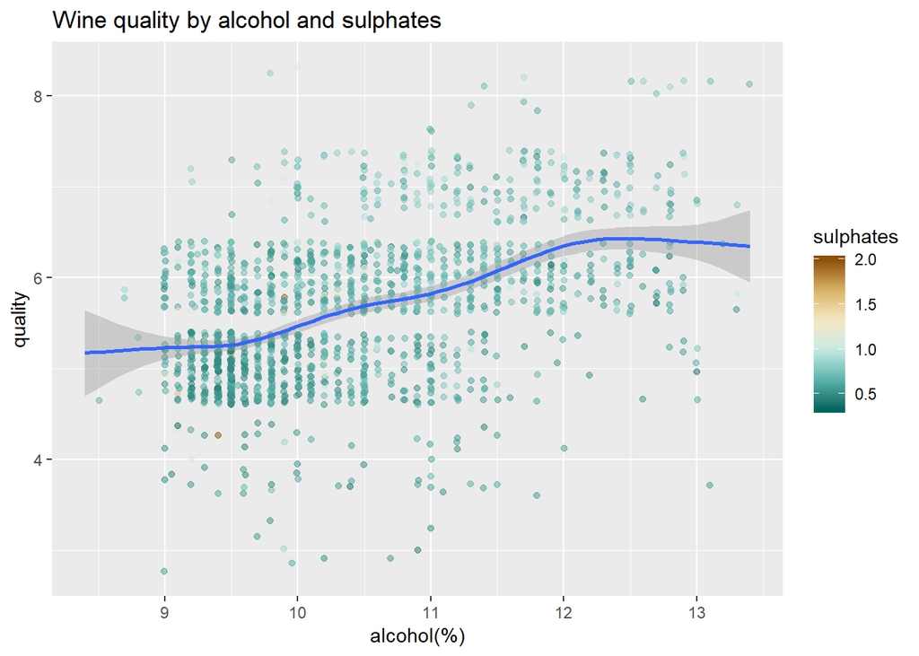

### Description Three

Both alcohol and sulphates have positive correlation with quality. When putting these three variables together, we can see there is a mild trend: higher alcohol, higer sulphates(under 1) have higher quality. But the correlation is not strong. Also, there are few samples have sulphates higher than 1.0.

# Reflection

When I started to explore the red wine dataset, I was very confused on what each variable means since I’m not familiar with wine at all. I did some research on google and read some articles to get better understanding. According to some articles, I believe pH and Sulphates are the most important attributes that impact the quality. So I decided to focus on the relationship between these two attributes and quality.

However, I was surprised I didn’t see strong correlations between them and quality at all, especially pH. In the plots sulphates shows mild positive correlation with quality(corr is 0.251). I had been thinking why this happened during the whole exploration. Surprisingly, Alcohol shows the strong correlation with quality among all the attributes(corr is 0.476).

After I explore more and more, I think the reason this happened is because that there is some limitation on the dataset. There are 1599 samples in total. And 1,319 out of 1,599 received a score of 5 or 6. No sample received scores of 0, 1, 9, or 10. Since the wine quality variable had such limited variability, it was difficult to assess the relationship between quality and the chemical attribute variables. If we have a greater variety of quality ratings we might get a better insight on how these attributes are related with quality. Also, quality rating is based on sensory data (median of at least 3 evaluations made by wine experts). It’s difficult to accurately describe and quantify.

Besides the attributes in the dataset, there are some other aspects that impact the quality, like the type of grape, the place and climate where the grape grow etc. There is another dataset of white wine, which I would like to do another exploration to compare with the data of red wine to see if there is any different pattern.

# Reference documents:

http://www.wineskills.co.uk/winemaking/winemaking-knowledge-base/sulphur-dioxide

http://winemakersacademy.com/importance-ph-wine-making/